# S1a_R brms

Ian Hajnosz

10/13/2021

# Loading in the Data

```r
library(readr)
df_anchor <- df <- read_csv("Ian+Study+1a_R_August+23,+2021_09.20.csv")
df$id <- 1:nrow(df)
```

Added a “df_anchor” object just to have a base dataframe to refer to

## Handling the Variable Columns

Removing unnecessary columns, Converting to appropriate data type

```r
library(dplyr)
library(tidyverse)
df <- select(df,
             -(StartDate:UserLanguage))
df <- select(df,
             -c(BFI_DO, EC_DO, Attach_DO, RNSF1_DO, KM_P_DO, KM_CSR_DO, KM_M_DO, KM_L_DO, RNSF2_DO, Q12.1_DO, SC0, FL_3_DO))

df <- df[-c(1,2), ] #remove the first two rows (meta-data)
df[, c(1:76, 78:79, 81:82, 84:88)] <-  sapply(df[, c(1:76, 78:79, 81:82, 84:88)], as.numeric) #making sure data is correct type
```

Renaming of columns into something more palatable

```r
df <- rename(df,
             Consent = Q1.2,
             Vid_SelfRep = Q12.1,
             Vid_Audio = Q12.4,
             Vid_Issue = Q12.2,
             Vid_Issue_TEXT = Q12.2_2_TEXT,
             Vid_PrevExp = Q12.3,
             Cond = FL_5_DO)

df <- mutate(df, Cond =
               recode(Cond,
                      'VideoCondition1"ThaiMedicine"Zickfeldetal.2019' = "1",
                      'VideoNeutral1"CleanHardwoodFloors"(Riveraetal.,2019)' = "0")
)
df$Vid_PrevExp <- factor(df$Vid_PrevExp)
df$Cond <- as.numeric(df$Cond)
```

## Pre-processing

```r
##Recoding amiss values
#Race
df$Race[df$Race_10_TEXT == "british asian-indian"] <- 9
df$Race[df$Race_10_TEXT == "White, Slavic"] <- 0

##Tidying Factor Variables (E.g.Demographics)
factor(df$Gender)#checking for levels used
```

```
##   [1] <NA> 1    1    1    0    0    1    0    0    0    0    0    1    1    0
##  [16] 0    0    1    1    0    1    1    0    1    1    0    0    1    1    1
##  [31] 0    1    1    1    1    1    1    0    1    1    1    1    0    0    1
##  [46] 1    1    1    0    1    0    0    0    0    0    0    1    0    0    1
##  [61] 0    0    1    0    0    0    1    0    1    1    0    0    0    0    1
##  [76] 0    1    0    0    0    1    0    1    1    1    1    1    0    0    0
##  [91] 0    1    0    0    0    1    0    0    0    0    0    1    1    1    0
## [106] 1    1    0    0    1    0    1    0    0    0    0    1    0    1    0
## [121] 0    0    0    1    1    0    0    1    0    1    0    1    1    1    0
## [136] 1    0    0    0    0    1    1    0    1    1    1    0    0    0    0
## [151] 1    1    1    1    1    0    1    0    1    0    0    0    0    0    0
## [166] 0    1    0    0    0    1    0    1    1    0    1    1    0    0    1
## [181] 1    1    1    1    0    1    1    1    1    1    0    0    0    1    1
## [196] 0    1    0    0    1    0    1    0    0    0    0    0    0    0    1
## [211] 0    0    0    1    1    1    1    0    0    1    0    0    1    1    0
## [226] 1    1    0    0    0    1    0    0    0    0    1    1    0    1    1
## [241] 0    1    1    1    1    0    1    1    0    1    0    1    1    1    0
## [256] 0    0    1    0    1    0    1    1    0    0    1    1    1    0    1
## [271] 0    1    0    1    1    1    1    0    1    0    1    0    1    0    0
## [286] 1    0    0    0    1    1    1    1    1    1    1    1    1    0    0
## [301] 0    1    0    <NA> <NA> <NA> <NA> <NA> <NA> <NA> <NA> <NA> <NA> 1
## Levels: 0 1
```

```r
df$Gender <- factor(df$Gender, labels = c(
  "Female", "Male"))
```

Now that those odd responses have been re-coded properly, we can make sure the variables are the correct type and are representing the correct things from the survey

```r
factor(df$Race)#checking for levels used
```

```
##   [1] <NA> 8    0    0    0    0    3    0    0    0    0    0    0    0    0
##  [16] 0    0    0    0    7    0    0    0    0    0    0    0    4    0    0
##  [31] 0    0    0    0    0    0    0    0    2    0    0    0    0    0    0
##  [46] 0    0    0    0    0    0    0    0    0    0    0    4    0    1    0
##  [61] 0    0    0    0    0    0    0    0    0    0    0    0    0    1    0
##  [76] 0    0    0    0    0    3    0    0    0    0    0    0    0    0    0
##  [91] 0    0    0    0    0    0    0    0    0    1    0    0    0    0    9
## [106] 2    0    0    9    0    0    0    0    0    0    0    0    0    0    0
## [121] 0    0    9    0    0    0    0    0    0    0    0    0    0    6    0
## [136] 0    0    0    0    0    2    1    7    0    0    0    0    0    0    0
## [151] 0    0    0    0    0    0    0    2    0    0    1    0    0    0    0
## [166] 0    0    0    0    0    0    0    0    0    0    0    0    0    0    0
## [181] 0    4    0    0    0    0    0    2    0    0    0    0    1    0    0
## [196] 0    0    0    0    0    3    0    0    0    0    0    10   0    0    0
## [211] 0    0    0    0    0    0    0    0    0    0    0    0    1    3    0
## [226] 0    0    0    0    9    0    9    0    0    0    0    0    0    0    0
## [241] 0    2    0    0    0    0    0    0    0    0    0    5    0    0    1
## [256] 0    0    0    0    0    0    0    0    0    0    0    0    0    0    0
## [271] 0    0    2    2    0    2    0    9    0    0    0    0    0    0    0
## [286] 0    0    7    2    0    0    0    0    0    0    0    0    0    0    0
## [301] 0    0    0    <NA> <NA> <NA> <NA> <NA> <NA> <NA> <NA> <NA> <NA> 0
## Levels: 0 1 2 3 4 5 6 7 8 9 10
```

```r
df$Race <- factor(df$Race, labels = c(
  "White, Caucasian, Anglo",
  "Black, African, Caribbean",
  "Hispanic, Latino/a, Chicano/a",
  "East Asian",
  "South Asian",
  "Southeast Asian",
  "West Asian",
  "Middle Easter, Arab",
  "Aboriginal, Indigenous, Native",
  "Mixed or Multiple Ethnic Groups",
  "Other"
))

factor(df$Education)#checking for levels used
```

```
##   [1] <NA> 2    3    0    4    4    3    3    5    3    3    3    1    3    1
##  [16] 4    3    4    4    3    4    4    2    4    4    1    3    1    2    1
##  [31] 3    3    3    2    1    4    0    0    0    1    1    3    2    3    5
##  [46] 4    1    2    2    0    1    4    3    3    3    3    4    3    2    0
##  [61] 4    3    1    1    2    3    3    3    4    3    3    3    3    3    3
##  [76] 5    4    3    3    4    5    3    3    1    2    4    3    3    4    3
##  [91] 4    3    3    3    1    5    1    3    0    3    5    1    1    1    3
## [106] 3    2    3    1    4    2    4    4    0    2    1    1    3    1    0
## [121] 1    1    3    3    1    4    1    3    4    1    4    4    1    3    2
## [136] 4    3    1    3    1    3    1    3    3    4    2    5    3    2    3
## [151] 4    3    3    4    2    3    4    3    0    4    3    4    4    1    4
## [166] 0    4    0    0    0    3    3    3    0    3    3    4    3    3    1
## [181] 0    3    3    4    3    3    1    3    3    0    1    3    6    1    3
## [196] 3    0    4    0    3    3    1    3    4    1    2    3    4    3    5
## [211] 3    4    4    4    0    3    3    4    2    1    3    2    3    3    3
## [226] 5    3    4    1    2    1    4    4    3    3    2    4    3    1    4
## [241] 3    3    3    1    3    3    1    3    3    3    4    4    3    4    3
## [256] 4    3    1    1    3    4    4    3    3    4    1    4    1    3    1
## [271] 2    4    3    3    2    3    3    3    1    1    2    3    0    4    4
## [286] 4    0    3    4    4    3    3    3    3    4    3    0    0    1    1
## [301] 3    0    4    <NA> <NA> <NA> <NA> <NA> <NA> <NA> <NA> <NA> <NA> 0
## Levels: 0 1 2 3 4 5 6
```

```r
df$Education <- factor(df$Education, labels = c(
  "GCSE, O-Levels, or Standard Grades",
  "A-Levels or Highers/Advanced Highers",
  "Vocational degree (e.g., SVQ, HNC, HND",
  "Undergraduate degree (e.g., BSc, BA)",
  "Master's degree (e.g., MSc, MPhil)",
  "PhD, PsyD",
  "Other advanced or professional degree (e.g., MD, JD)"
))

df$Student <- factor(df$Student, labels = c(
  "No", "Yes"
))

df$Employed <- factor(df$Employed, labels = c(
  "No",
  "Yes, part-time",
  "Yes, full-time"
))

factor(df$Income)#checking levels used
```

```
##   [1] <NA> 3    0    1    3    3    2    3    0    2    0    3    3    4    0
##  [16] 2    2    3    3    0    0    3    1    2    4    4    3    4    0    2
##  [31] 5    2    2    0    0    0    2    0    1    3    0    2    0    0    4
##  [46] 0    2    0    2    0    4    3    3    4    3    4    4    3    0    2
##  [61] 3    2    4    4    2    1    3    1    0    2    2    4    4    4    4
##  [76] 4    0    0    4    0    4    3    1    2    2    2    1    3    3    3
##  [91] 1    1    3    1    0    4    2    5    0    1    3    3    0    3    1
## [106] 0    1    3    2    1    2    0    3    2    1    0    2    2    4    3
## [121] 4    1    4    0    0    2    1    1    0    3    2    4    2    0    3
## [136] 2    1    2    3    3    1    1    0    4    4    1    4    0    0    0
## [151] 0    3    0    4    2    0    2    5    1    4    3    2    3    1    1
## [166] 4    0    0    4    0    2    2    2    4    4    1    3    4    0    2
## [181] 2    0    2    1    4    1    2    2    2    2    0    0    0    3    4
## [196] 1    1    0    1    0    3    3    4    3    0    2    0    4    0    5
## [211] 3    4    2    0    2    3    0    3    0    2    3    4    0    3    3
## [226] 0    1    2    4    0    2    2    3    2    1    1    3    4    4    4
## [241] 3    3    3    0    2    2    0    3    0    0    3    3    2    3    3
## [256] 1    1    3    3    2    1    3    3    0    2    2    3    1    0    0
## [271] 4    2    3    0    0    2    0    1    4    0    0    3    1    2    1
## [286] 2    3    3    3    3    3    0    0    4    4    3    2    5    4    0
## [301] 2    4    4    <NA> <NA> <NA> <NA> <NA> <NA> <NA> <NA> <NA> <NA> 0
## Levels: 0 1 2 3 4 5
```

```r
df$Income <- factor(df$Income, labels = c(
  "£0-£12,500",
  "£12,501-£14,549",
  "£14,550-£24,944",
  "£24,945-£43,430",
  "£43,431-£150,000",
  "£150,001+"
))

factor(df$SexualOr)
```

```
##   [1] <NA> 4    0    0    0    0    0    0    0    0    2    0    0    0    0
##  [16] 0    0    4    0    4    0    0    0    0    0    0    4    5    0    0
##  [31] 0    0    0    0    0    0    0    0    0    0    0    0    0    0    0
##  [46] 0    0    0    4    0    3    0    0    0    0    0    0    0    0    0
##  [61] 0    4    4    2    0    0    0    0    0    0    0    0    2    0    0
##  [76] 0    0    7    0    4    1    0    0    0    0    0    0    0    0    0
##  [91] 0    0    0    0    0    0    0    0    0    0    0    0    0    0    0
## [106] 0    0    0    0    0    0    0    4    0    0    0    4    0    0    0
## [121] 0    0    0    0    1    2    4    5    7    0    0    0    1    0    0
## [136] 0    0    0    0    0    0    0    0    0    0    0    0    0    0    4
## [151] 0    0    0    0    0    0    0    4    0    0    0    4    0    0    0
## [166] 3    0    0    0    6    0    0    0    0    4    1    0    0    0    0
## [181] 5    0    0    0    0    0    0    0    0    4    0    0    0    0    0
## [196] 0    0    0    0    0    0    0    2    4    0    0    4    0    0    4
## [211] 0    0    0    0    0    0    0    0    0    0    0    0    0    0    0
## [226] 0    0    0    0    0    0    0    0    0    0    0    0    0    4    0
## [241] 0    0    0    0    0    0    4    0    0    0    0    0    0    0    0
## [256] 0    4    0    0    0    0    0    0    0    0    0    0    4    0    0
## [271] 0    0    0    0    0    0    0    7    0    5    4    6    0    0    0
## [286] 1    4    0    0    0    0    0    0    0    0    0    0    0    4    4
## [301] 4    4    0    <NA> <NA> <NA> <NA> <NA> <NA> <NA> <NA> <NA> <NA> 0
## Levels: 0 1 2 3 4 5 6 7
```

```r
df$SexualOr <- factor(df$SexualOr, labels = c(
  "Heterosexual, Straight",
  "Gay",
  "Lesbian",
  "Queer",
  "Bisexual, Pansexual",
  "Demisexual",
  "Asexual",
  "Other"
))
```

# Construct Tabulation

We have a couple of constructs to put together, properly reverse scoring certain items as well. First we’ll do the personality measure

```r
##reverse-scored items and creating collated Scores

##BFI Personality
#reverse coding equation: (total available responses +1) - score
#Extraversion: items 1R, 6, 11
df$BFI_1R <- (7+1) - df$BFI_1
df$BFI_E <- rowMeans(df[,c('BFI_1R', 'BFI_6', 'BFI_11')], na.rm = T)

#Agreeableness 2,7R,12
df$BFI_7R <- (7+1) - df$BFI_7
df$BFI_A <- rowMeans(df[,c('BFI_2', 'BFI_7R', 'BFI_12')], na.rm = T)

#Conscientiousness: 3R, 8R, 13
df$BFI_3R <- (7+1) - df$BFI_3
df$BFI_8R <- (7+1) - df$BFI_8
df$BFI_C <- rowMeans(df[,c('BFI_3R', 'BFI_8R', 'BFI_13')], na.rm = T)

#Neuroticism: 4,9,14R
df$BFI_14R <- (7+1) - df$BFI_14
df$BFI_N <- rowMeans(df[,c('BFI_4', 'BFI_9', 'BFI_14R')], na.rm = T)

#Openmindedness: 5, 10R, 15
df$BFI_10R <- (7+1) - df$BFI_10
df$BFI_O <- rowMeans(df[,c('BFI_5', 'BFI_10R', 'BFI_15')], na.rm = T)
```

Now to Empathic Concern

```r
##EC Empathic Concern IRI
#should be on 0-4 scale, not 1-5
df[, c("EC_1","EC_2", "EC_3", "EC_4","EC_5","EC_6", "EC_7")] <- df[, c("EC_1","EC_2", "EC_3", "EC_4","EC_5","EC_6", "EC_7")]-1
#reverse coding equation, incl a zero point: (total available responses-1) - score
#items: 1, 2R, 3, 4R, 5R, 6, 7
df$EC_2R <- 4 - df$EC_2
df$EC_4R <- 4 - df$EC_4
df$EC_5R <- 4 - df$EC_5
df$EC <- rowMeans(df[, c("EC_1", "EC_2R", "EC_3", "EC_4R", "EC_5R", "EC_6", "EC_7")], na.rm = T)
```

Now to Global Attachment

```r
##Attach General/Global Attachment
#reverse coding equation: (total available responses +1) - score
#Attachment Avoidance items: 1R, 2R, 3R, 4R, 5 , 6
df$Attach_1R <- 8 - df$Attach_1
df$Attach_2R <- 8 - df$Attach_2
df$Attach_3R <- 8 - df$Attach_3
df$Attach_4R <- 8 - df$Attach_4
df$Attach_avd <- rowMeans(df[, c("Attach_1R", "Attach_2R", "Attach_3R", "Attach_4R", "Attach_5", "Attach_6")], na.rm = T)
#Attachment Anxiety items: 7,8,9
df$Attach_anx <- rowMeans(df[, c("Attach_7", "Attach_8", "Attach_9")], na.rm = T)
```

Now to Relatedness Needs Time 1

```r
##RNSF1 Relatedness Needs Satisfaction/Frustration Time 1
#RNS items: 1, 2, 3, 4
df$RNS1 <- rowMeans(df[, c("RNSF1_1","RNSF1_2","RNSF1_3","RNSF1_4")])
#RNF items: 5,6,7,8
df$RNF1 <- rowMeans(df[, c("RNSF1_5","RNSF1_6","RNSF1_7","RNSF1_8")])
```

Now to Kama Muta Each of kama muta’s five aspects should be on a 0-6 scale, not the 1-7 scale it currently is. So let’s fix that first:

```r
df[, c("KM_P_1","KM_P_2", "KM_P_3", "KM_P_4" ,"KM_P_5", "KM_P_6", "KM_P_7", "KM_P_8", "KM_P_9", "KM_P_10", "KM_P_11","KM_P_12")] <-
  df[, c("KM_P_1","KM_P_2", "KM_P_3", "KM_P_4" ,"KM_P_5", "KM_P_6", "KM_P_7", "KM_P_8", "KM_P_9", "KM_P_10", "KM_P_11","KM_P_12")]-1

df[, c("KM_CSR_1","KM_CSR_2","KM_CSR_3", "KM_CSR_4", "KM_CSR_5")] <-
  df[, c("KM_CSR_1","KM_CSR_2","KM_CSR_3", "KM_CSR_4", "KM_CSR_5")]-1

df[, c("KM_M_1","KM_M_2", "KM_M_3", "KM_M_4")] <-
  df[, c("KM_M_1","KM_M_2", "KM_M_3", "KM_M_4")]-1

df[, ("KM_PA_1")] <-
  df[, ("KM_PA_1")]-1

df[, c("KM_L_1", "KM_L_2", "KM_L_3")] <-
  df[, c("KM_L_1", "KM_L_2", "KM_L_3")]-1
```

Now we can condense them together into individual aspects

```r
df$KM_P <- rowMeans(df[, c("KM_P_1","KM_P_2", "KM_P_3", "KM_P_4" ,"KM_P_5", "KM_P_6", "KM_P_7", "KM_P_8", "KM_P_9", "KM_P_10", "KM_P_11","KM_P_12")], na.rm = T)
df$KM_CSR <- rowMeans(df[, c("KM_CSR_1","KM_CSR_2","KM_CSR_3", "KM_CSR_4")], na.rm = T)  #note, KM_CSR_5 not included here b/c it was a attention check item, not part of the scale
df$KM_M <- rowMeans(df[, c("KM_M_1","KM_M_2", "KM_M_3", "KM_M_4")], na.rm = T)
df$KM_PA <- df$KM_PA_1
df$KM_L <- rowMeans(df[, c("KM_L_1", "KM_L_2", "KM_L_3")], na.rm = T)
```

Note that one of our variables, KM_CSR_5 was actually a sneaked-in attention check, thus we didn’t use it in the KM_CSR scoring. Let’s call out that attention check clearly now and remove the confusing variable

```r
#Attention check was placed on KM_CSR_5
df$AttCheck <- df$KM_CSR_5 #correct answer "Not at all" is coded as 0
df <- select(df, -KM_CSR_5)
```

Now to Relatedness Needs (again) but Time 2

```r
##RNSF2 Relatedness Needs Satisfaction/Frustration Time 2
#RNS items: 1, 2, 3, 4
df$RNS2 <- rowMeans(df[, c("RNSF2_1","RNSF2_2","RNSF2_3","RNSF2_4")])
#RNF items: 5,6,7,8
df$RNF2 <- rowMeans(df[, c("RNSF2_5","RNSF2_6","RNSF2_7","RNSF2_8")])
```

### Now that we have our variables mostly coded, let’s look at discrepancies

First attention checks

```r
##Checking attention check, correct answer "Not at all" is coded as 0
table((df$AttCheck[df$AttCheck != 0]), exclude = NULL) #8 failed attention checks
```

```
##
##    2    3    5    6 <NA>
##    1    4    2    1    8
```

```r
df$AttCheck <- ifelse(df$AttCheck == 0,
                      "Pass",
                      "Fail")
```

How about issues with watching the video?

```r
unique(df$Vid_Issue_TEXT)
```

```
## [1] NA                                  "Had to watch on YouTube app"
## [3] "video was intermittent"            "Can only stop and start on mobile"
```

```r
length(unique(df$Vid_Issue_TEXT))-1 #3 total issues;NA is counted as "unique" so removing by 1 that to get true count
```

```
## [1] 3
```

```r
nrow(df) - sum(is.na(df$Vid_Issue_TEXT))#3, alternative calculation of NAs and non-NAs in the video issue text var
```

```
## [1] 3
```

```r
df$Vid_Issue <- factor(df$Vid_Issue)
```

Ok, to make sure our final n we’re dealing with is clean of exclusion problems, lets go top to bottom filtering out problem participants, checking along the way how many got caught out

First by consent Second by passing attention check

```r
##Segmenting Out for Final df, by priority of importance
nrow(df) #initial check
```

```
## [1] 314
```

```r
#consent, must be confirmed
df <- subset(df, Consent == 1)

#attention check, must be successful.
df <- subset(df, AttCheck == "Pass")

nrow(df)#after those "hard" cuts, we're down to 298
```

```
## [1] 298
```

Third by correctly reporting that they watched the video presented to them This is a bit trickier to line up what they said with what we know they saw, AND by what condition that forced them to watch one or the other

```r
#video condition/self-report confirmation
#3 == KM video, 7 == floor clean video: Conditions 1 KM, 0 Neutral
df$Vid_Check <- paste(df$Vid_SelfRep, df$Cond) #only want "3 1" or " 7 0", all other combinations are incorrect
table(df$Vid_Check, exclude = NULL) #looks like 1 failed check, 4 NA checks (people who were assigned conditions but didn't get to responding, likely from test runs). 146/147 exp/con split
```

```
##
##  3 1  7 0  7 1 NA 0 NA 1
##  146  147    1    2    2
```

```r
df$Vid_Check <- ifelse(df$Vid_Check == "3 1" | df$Vid_Check == "7 0",
                       "Pass",
                       "Fail")
table(df$Vid_Check, exclude = NULL) #Confirmed, 5 fail, 293 pass
```

```
##
## Fail Pass
##    5  293
```

```r
df$Cond <- factor(df$Cond, levels = c(0, 1), labels = c("Control", "KM"))

#Vid condition check,successful
df <- subset(df, Vid_Check == "Pass")

nrow(df)# current 293, confirmed 5 cut from the video attention check
```

```
## [1] 293
```

### Ok now let’s create our final variables that we’ll be using

First, the probability of experiencing kama muta, pKM. This is a quantitative formalization of how, at this point, the KAMMUS Two scale is really about showing the likelihood a given experience is kama muta based on the co-occurence of these 5 aspects. This is an explicit quantification of that concept by using a sigmoid function, the S curve used in logistic regressions. We do some scaling of the kama muta variables to make that fit (e.g. the sigmoid(0) refers to a 50% likelihood, meaning we need the kama muta variables scaled such that getting, e.g., 3 out of 7 (the middle point) on all five aspects should will be scaled to 0. We do this via subtracting 3 from the average of KM variables and dividing by 1. After that, we have values capapble of fitting into a sigmoid function

```r
#Pre-Analysis variable creation
##I need to make averages of each part first
df$KM_Avg <- (df$KM_P + df$KM_CSR + df$KM_M + df$KM_PA + df$KM_L)/5
#b/c sigmoid(0) = 0.5, you need the input values to be both above and below 0 to access the full 0.0-1.0 function range.
#a simple zscore would make the mean of the data the zero point, which is not what we want. We want the middlest point of the SCALE to reflect the zero point.
df$KM_Scl <- (df$KM_Avg - 3)/1 #scaling such that the "mean" is == 0. I.e. if a participant had an avg resp of 3 (the middle of the 0-6 range) across all 5 KM sections, they would get a 0, therefore a 50% probability KM
df$pKM <- 1/(1+(exp(1)^-(df$KM_Scl))) #sigmoid function: 1/(1+e^-x)
```

Now we have our variables of interest, we can standardize them

```r
#standardize data

df$pKM_Z <- scale(df$pKM)
df$RNF1_Z <- scale(df$RNF1)
df$RNF2_Z <- scale(df$RNF2)
df$RNS1_Z <- scale(df$RNS1)
df$RNS2_Z <- scale(df$RNS2)
df$Attach_anx_Z <- scale(df$Attach_anx)
df$Attach_avd_Z <- scale(df$Attach_avd)
```

### Visualizing what we have

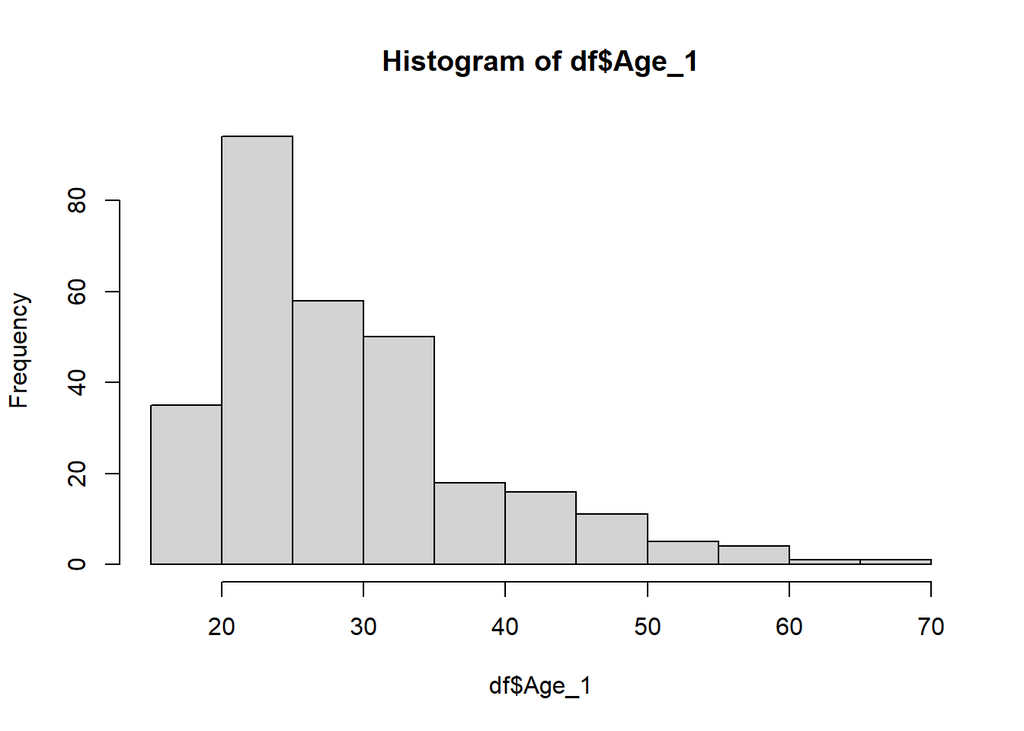

```r
#demographic distributions, histograms(age, race/ethnicity, gender)
library(ggplot2)
library(gridExtra)
library(viridis)
hist(df$Age_1)
```

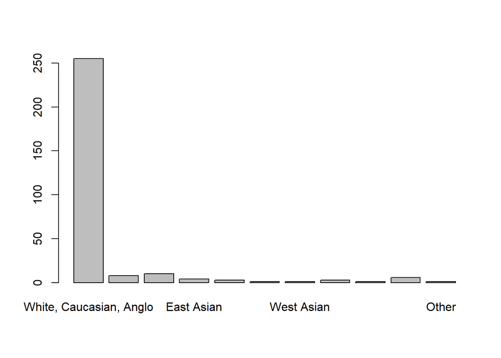

```r
plot(df$Race)
```

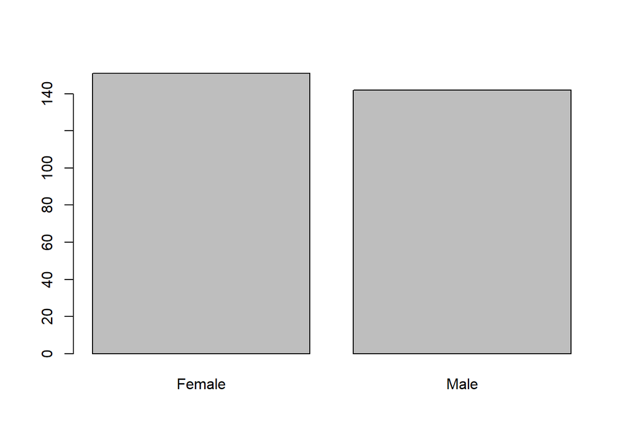

```r
plot(df$Gender)
```

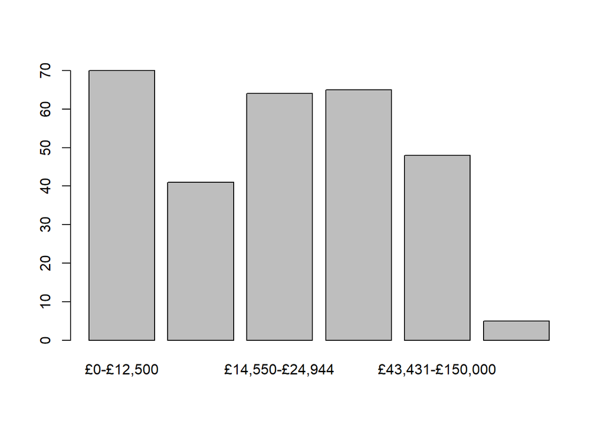

```r
plot(df$Income)
```

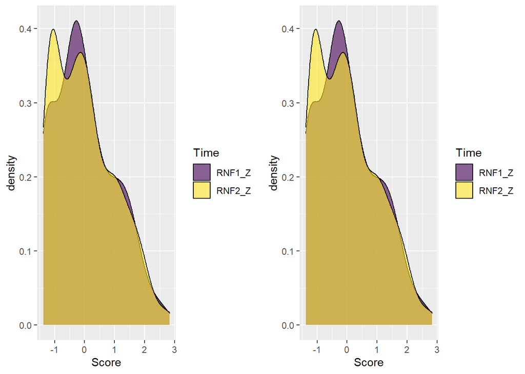

```r
df_p <- df %>%
  select("RNF1_Z", "RNF2_Z") %>%
  pivot_longer(cols = c("RNF1_Z", "RNF2_Z"),
               names_to = "Time",
               values_to = "Score")


p1 <- ggplot(df_p, aes(Score, group = Time, fill = Time)) +
  geom_density(alpha = 0.6) +
  scale_fill_viridis(discrete = T) +
  scale_color_viridis(discrete = T)

p2 <- ggplot(df_p, aes(Score, group = Time, fill = Time)) +
  geom_density(alpha = 0.6) +
  scale_fill_viridis(discrete = T) +
  scale_color_viridis(discrete = T)

grid.arrange(p1,p2, nrow = 1)
```

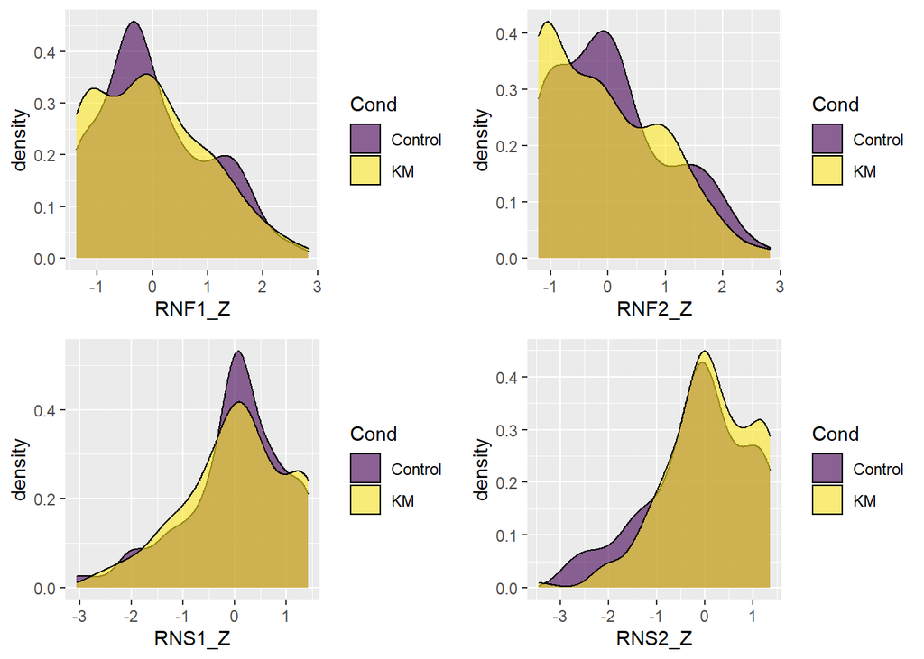

```r
p1 <- ggplot(df, aes(RNF1_Z, group = Cond, fill = Cond)) +
  geom_density(alpha = 0.6) +
  scale_fill_viridis(discrete=TRUE) +
  scale_color_viridis(discrete=TRUE)

p2 <- ggplot(df, aes(RNF2_Z, group = Cond, fill = Cond)) +
  geom_density(alpha = 0.6) +
  scale_fill_viridis(discrete=TRUE) +
  scale_color_viridis(discrete=TRUE)

p3 <- ggplot(df, aes(RNS1_Z, group = Cond, fill = Cond)) +
  geom_density(alpha = 0.6) +
  scale_fill_viridis(discrete=TRUE) +
  scale_color_viridis(discrete=TRUE)

p4 <- ggplot(df, aes(RNS2_Z, group = Cond, fill = Cond)) +
  geom_density(alpha = 0.6) +
  scale_fill_viridis(discrete=TRUE) +
  scale_color_viridis(discrete=TRUE)

grid.arrange(p1,p2,p3,p4, nrow = 2)
```

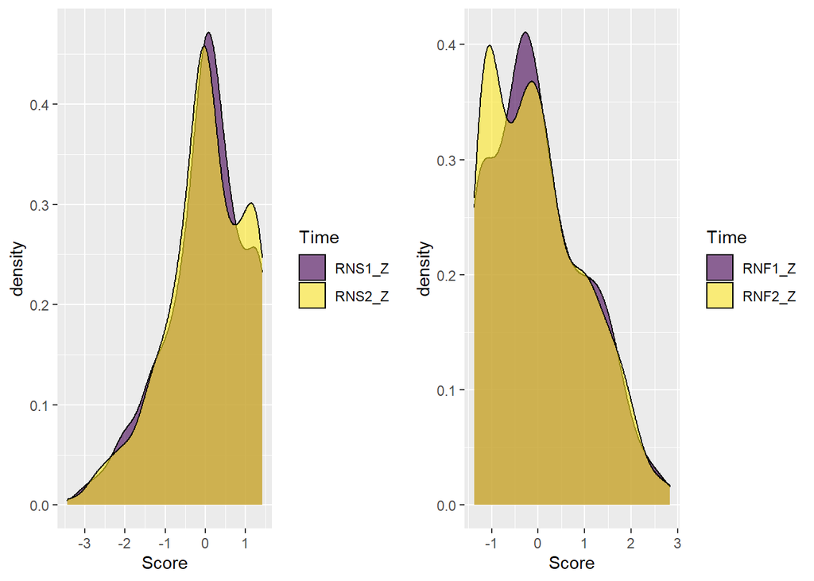

```r
df_p <- df %>%
  select("RNS1_Z", "RNS2_Z") %>%
  pivot_longer(cols = c("RNS1_Z", "RNS2_Z"),
               names_to = "Time",
               values_to = "Score")
p1 <- ggplot(df_p, aes(Score, group = Time, fill = Time)) +
  geom_density(alpha = 0.6) +
  scale_fill_viridis(discrete = T) +
  scale_color_viridis(discrete = T)

df_p <- df %>%
  select("RNF1_Z", "RNF2_Z") %>%
  pivot_longer(cols = c("RNF1_Z", "RNF2_Z"),
               names_to = "Time",
               values_to = "Score")

p2 <- ggplot(df_p, aes(Score, group = Time, fill = Time)) +
  geom_density(alpha = 0.6) +
  scale_fill_viridis(discrete = T) +
  scale_color_viridis(discrete = T)

grid.arrange(p1,p2, nrow = 1)
```

pKM by Condition

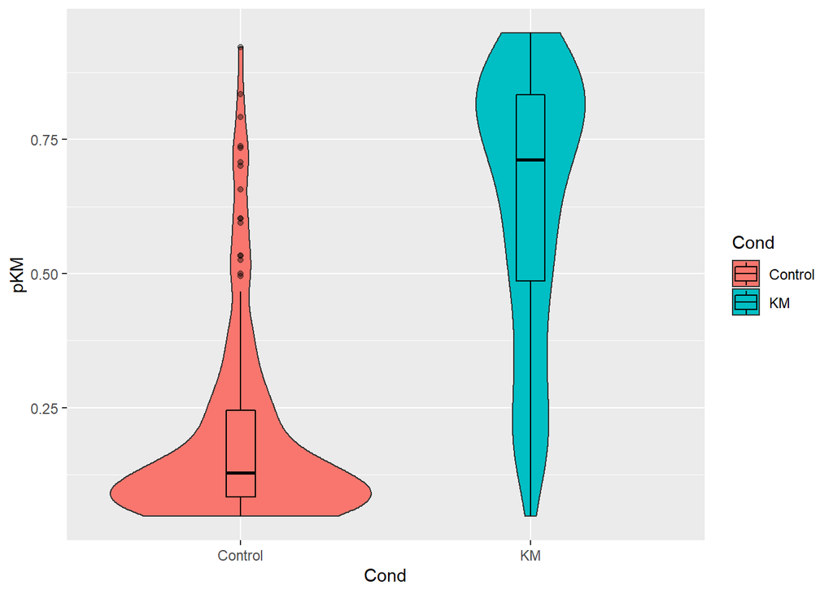

```r
ggplot(df, aes(Cond, pKM, fill = Cond)) +
  geom_violin() +
  geom_boxplot(width = 0.1, color = "black", alpha = 0.4)
```

KM aspects by Condition

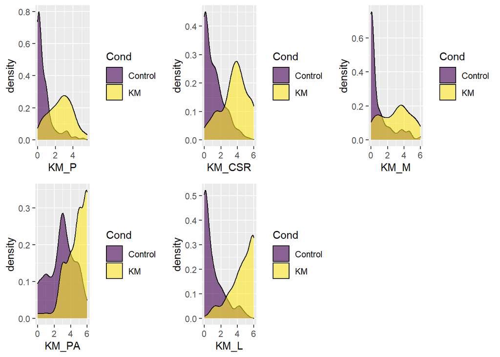

```r
p1 <- ggplot(df, aes(KM_P, group = Cond, fill = Cond)) +
  geom_density(alpha = 0.6) +
  scale_fill_viridis(discrete=TRUE) +
  scale_color_viridis(discrete=TRUE)

p2 <- ggplot(df, aes(KM_CSR, group = Cond, fill = Cond)) +
  geom_density(alpha = 0.6) +
  scale_fill_viridis(discrete=TRUE) +
  scale_color_viridis(discrete=TRUE)

p3 <- ggplot(df, aes(KM_M, group = Cond, fill = Cond)) +
  geom_density(alpha = 0.6) +
  scale_fill_viridis(discrete=TRUE) +
  scale_color_viridis(discrete=TRUE)

p4 <- ggplot(df, aes(KM_PA, group = Cond, fill = Cond)) +
  geom_density(alpha = 0.6) +
  scale_fill_viridis(discrete=TRUE) +
  scale_color_viridis(discrete=TRUE)

p5 <- ggplot(df, aes(KM_L, group = Cond, fill = Cond)) +
  geom_density(alpha = 0.6) +
  scale_fill_viridis(discrete=TRUE) +
  scale_color_viridis(discrete=TRUE)

grid.arrange(p1,p2,p3,p4,p5, nrow = 2)
```

Let’s see if technical difficulties made big differences. I.e. did people who have tech difficulties very different from the rest of the sample?

```r
table(df$Vid_Issue, df$Cond) #no huge difference between conditions on tech difficulties. Only a few anyway
```

```
##
##     Control  KM
##   1     146 145
##   2       1   1
```